# CSC421 Fall 2023 Assignment 4

### Author: George Tzanetakis

This notebook is based on the topics covered in **Chapter 18 Learning ** and **Chapter 21 Deep Learning from the book *Artificial Intelligence: A Modern Approach.* You are welcome and actually it can be educational to look at the code at the aima-code repository as well as other code resources you can find on the web. However, make sure you understand any code that you incoporate.

The assignment structure is as follows - each item is worth 1 point:

1. Create mini CIFAR-10 (Basic)
2. SVM classification of CIFAR-10 (Basic)
3. Naive Bayes Gaussian (Expected)
4. Sort classes by prediction accuracy (Basic)
5. Show misclassification examples (Expected)
6. Compare raw image, histogram-of-gradients, and principal component analysis of hogs (Expected)
7. Change batch size and optimizer and compare (Basic)
8. Add noise to test images (Expected)
9. Generate synthetic dataset (4 colors, 4 shapes, 4 sizes, 4 x positions, 4 y positions) (Advanced)
10. Deep learning classification of synthetic dataset (Advanced)

# Question 1 (Basic) Create mini CIFAR-10

Re-use the code from the deep learning notebook to load the CIFAR-10 training and test datasets. Create a mini CIFAR-10 dataset with 5000 instances for training and 5000 instances for testing. The examples in CIFAR-10 are randomly shuffled so you can simply take the first 5000 examples of each dataset. Print the shape of the resulting training set and test set.

```python
# Your code goes here
import torch
import torchvision
import torchvision.transforms as transforms
from tabulate import tabulate
import matplotlib.pyplot as plt
import numpy as np
import torch.nn as nn
import torch.nn.functional as F
from torchsummary import summary
import torch.optim as optim
from sklearn import datasets, metrics, svm
from sklearn.naive_bayes import GaussianNB
from sklearn.metrics import classification_report
import skimage
from sklearn.metrics import confusion_matrix, ConfusionMatrixDisplay
import utils
```

```python
transform = transforms.Compose(
    [transforms.ToTensor(),
     transforms.Normalize((0.5, 0.5, 0.5), (0.5, 0.5, 0.5))])

batch_size = 32


# CIFAR Canadian Institute for Advanced Research
# 2009 Tiny images object classificatino - AlexNet
# Reported training times from 2014 - 20 minutes


trainset = torchvision.datasets.CIFAR10(root='./data', train=True,
                                        download=True, transform=transform)
trainloader = torch.utils.data.DataLoader(trainset, batch_size=batch_size,
                                          shuffle=True, num_workers=4)

testset = torchvision.datasets.CIFAR10(root='./data', train=False,
                                       download=True, transform=transform)
testloader = torch.utils.data.DataLoader(testset, batch_size=batch_size,
                                         shuffle=False, num_workers=4)

classes = ('plane', 'car', 'bird', 'cat',
           'deer', 'dog', 'frog', 'horse', 'ship', 'truck')

trainset.data = trainset.data[:5000]
trainset.targets = trainset.targets[:5000]

testset.data = testset.data[:5000]
testset.targets = testset.targets[:5000]

print('Training set')
print(f'Samples: {trainset.data.shape}')
print(f'Labels: {len(trainset.targets)}')

print('\nTest set')
print(f'Samples: {testset.data.shape}')
print(f'Labels: {len(testset.targets)}')

print('\nClasses\n')
print(tabulate(
    list(trainset.class_to_idx.items()), headers=['Name', 'Index'],
    tablefmt='orgtbl'
))
```

```
Files already downloaded and verified
Files already downloaded and verified
Training set
Samples: (5000, 32, 32, 3)
Labels: 5000

Test set
Samples: (5000, 32, 32, 3)
Labels: 5000

Classes

| Name       |   Index |
|------------+---------|
| airplane   |       0 |
| automobile |       1 |
| bird       |       2 |
| cat        |       3 |
| deer       |       4 |
| dog        |       5 |
| frog       |       6 |
| horse      |       7 |
| ship       |       8 |
| truck      |       9 |
```

# Question 2 (Basic) - SVM

Train a SVM classifier on PCA dimensionality reduced Histogram of Oriented Gradients features. You can re-use the code from the deep learning notebook but instead of using the full training and testing sets use the mini-CIFAR-10 datset you created in question 1. Report the classification accuracy and confusion matrix.

```python
# Your code goes here

print('Training set')
print(f'Samples: {trainset.data.shape}')
print(f'Labels: {len(trainset.targets)}')
print(type(trainset.data))
print(type(trainset.targets))
print('\nTest set')
print(f'Samples: {testset.data.shape}')
print(f'Labels: {len(testset.targets)}')

train_n_samples = len(trainset.data)
print(train_n_samples)
test_n_samples = len(testset.data)
print(test_n_samples)

Xtrain = trainset.data
Xtest  = testset.data



from skimage.feature import hog
Xtrain_hog = []
for i in range(len(Xtrain)):
    fd  = hog(Xtrain[i] , orientations=9 , pixels_per_cell = (8,8),
                     cells_per_block = (2,2) , visualize = False, channel_axis=-1)
    Xtrain_hog.append(fd)
    if ((i % 10000) == 0):
        print(i)

Xtrain_hog = np.array(Xtrain_hog)
print('Done calculating HOGs for training')
print(Xtrain_hog.shape)

Xtest_hog = []
for i in range(len(Xtest)):
    fd = hog(Xtest[i] , orientations=9 , pixels_per_cell = (8,8),
                     cells_per_block = (2,2) , visualize = False, channel_axis=-1)
    Xtest_hog.append(fd)
    if ((i % 1000) == 0):
        print(i)

Xtest_hog = np.array(Xtest_hog)
print('Done calculating HOGs for testing')

ytrain = trainset.targets
ytest  = testset.targets

from sklearn.decomposition import PCA
pca = PCA(0.8)
Xtrain_pca = pca.fit_transform(Xtrain_hog)
Xtest_pca  = pca.transform(Xtest_hog)
print(Xtrain_pca.shape)
print(Xtest_pca.shape)
```

```
Training set
Samples: (5000, 32, 32, 3)
Labels: 5000
<class 'numpy.ndarray'>
<class 'list'>

Test set
Samples: (5000, 32, 32, 3)
Labels: 5000
5000
5000
0
Done calculating HOGs for training
(5000, 324)
0
1000
2000
3000
4000
Done calculating HOGs for testing
(5000, 63)
(5000, 63)
```

```
              precision    recall  f1-score   support

           0       0.55      0.62      0.58       488
           1       0.69      0.70      0.69       505
           2       0.47      0.47      0.47       512
           3       0.36      0.35      0.36       497
           4       0.48      0.48      0.48       507
           5       0.41      0.38      0.39       488
           6       0.58      0.63      0.61       491
           7       0.62      0.56      0.59       495
           8       0.61      0.64      0.62       504
           9       0.67      0.64      0.65       513

    accuracy                           0.55      5000
   macro avg       0.55      0.55      0.55      5000
weighted avg       0.55      0.55      0.55      5000
```

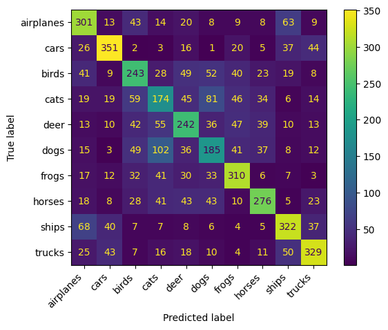

```
CPU times: total: 13.8 s
Wall time: 14.5 s
```

```python
%%time

# Create a classifier: a support vector classifier
clf = svm.SVC(C=10, cache_size=10000)
clf.fit(Xtrain_pca, ytrain)

ytest_predict  = clf.predict(Xtest_pca)
print(classification_report(ytest, ytest_predict))


color = 'white'
cm_sv = confusion_matrix(ytest, ytest_predict)
disp = ConfusionMatrixDisplay(cm_sv, display_labels=['airplanes', 'cars', 'birds', 'cats', 'deer', 'dogs', 'frogs', 'horses', 'ships', 'trucks'])
disp.plot()
plt.xticks(rotation=45, ha='right')
plt.show()
```

# Question 3 (Expected) - Gaussian Naive Bayes Classifier

Repeat the training and evaluation of the mini-CIFAR-10 dataset using the Gaussian Naive Bayes classifier from scikit-learn: [Gaussian Naive Bayes](https://scikit-learn.org/stable/modules/generated/sklearn.naive_bayes.GaussianNB.html) Similarly report on the classification accuracy and confusion matrix.

```
              precision    recall  f1-score   support

           0       0.49      0.50      0.50       488
           1       0.61      0.59      0.60       505
           2       0.40      0.36      0.38       512
           3       0.38      0.28      0.32       497
           4       0.38      0.49      0.43       507
           5       0.39      0.35      0.37       488
           6       0.45      0.68      0.54       491
           7       0.56      0.49      0.52       495
           8       0.53      0.51      0.52       504
           9       0.61      0.55      0.57       513

    accuracy                           0.48      5000
   macro avg       0.48      0.48      0.47      5000
weighted avg       0.48      0.48      0.47      5000
```

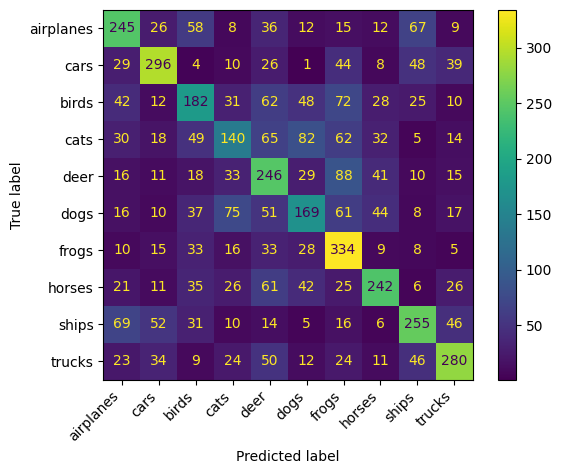

```
CPU times: total: 344 ms
Wall time: 370 ms
```

```python
%%time
# YOUR CODE GOES HERE

# Create a classifier: a Gaussian Naive Bayes Classifier
nb = GaussianNB()
nb.fit(Xtrain_pca, ytrain)

ytest_predict  = nb.predict(Xtest_pca)
print(classification_report(ytest, ytest_predict))

color = 'white'
cm_nb = confusion_matrix(ytest, ytest_predict)
disp = ConfusionMatrixDisplay(cm_nb, display_labels=['airplanes', 'cars', 'birds', 'cats', 'deer', 'dogs', 'frogs', 'horses', 'ships', 'trucks'])
disp.plot()
plt.xticks(rotation=45, ha='right')
plt.show()
```

# Question 4 (Expected) - Sort classes by prediction accuracy

Write a function that takes as input the computed confusion matrix and returns a list of classes sorted by classification accuracy. Each item in the list should be a tuple of the form (class, accuracy). Show the outpput for the SVM and Gaussian NB classifiers for the mini CIFAR-10 dataset.

```python
# Your answer goes here

def class_accuracy(conf_matrix):
    accuracy = []
    totals = np.sum(conf_matrix, 0)
    for i in range(len(conf_matrix[0])):
        accuracy.append((classes[i], conf_matrix[i][i]/totals[i]))
    return accuracy

sv_acc = class_accuracy(cm_sv)
nb_acc = class_accuracy(cm_nb)

sv_acc = sorted(sv_acc, key=lambda x: x[1], reverse=True)
nb_acc = sorted(nb_acc, key=lambda x: x[1], reverse=True)


print("Support Vector Classifier")
print(tabulate(
    sv_acc, headers=['Name', 'Accuracy'],
    tablefmt='orgtbl'
))

print("\nGaussian Naive Bayes Classifier")
print(tabulate(
    nb_acc, headers=['Name', 'Accuracy'],
    tablefmt='orgtbl'
))
```

```
Support Vector Classifier
| Name   |   Accuracy |
|--------+------------|
| car    |   0.690945 |
| truck  |   0.668699 |
| horse  |   0.621622 |
| ship   |   0.611006 |
| frog   |   0.583804 |
| plane  |   0.554328 |
| deer   |   0.477318 |
| bird   |   0.474609 |
| dog    |   0.406593 |
| cat    |   0.361746 |

Gaussian Naive Bayes Classifier
| Name   |   Accuracy |
|--------+------------|
| car    |   0.610309 |
| truck  |   0.607375 |
| horse  |   0.558891 |
| ship   |   0.533473 |
| plane  |   0.489022 |
| frog   |   0.450742 |
| bird   |   0.399123 |
| dog    |   0.39486  |
| deer   |   0.381988 |
| cat    |   0.375335 |
```

# Question 5 (Expected) - Show misclassification examples

Write a function that takes as input a particular class (for example dog) and shows an array of images (similar to the functions showing images in the deep learning notebook) in which each row contains 10 example images from another class that were misclassified. The resulting grid will have 9 rows (one for each class other than the input class) and 10 examples. For example the row for truck would have images of trucks that were misclassified as dogs. Show the output of this function for the SVM classifier and the class horse.

```python
%%time

# Create a classifier: a support vector classifier
clf = svm.SVC(C=10, cache_size=10000)
clf.fit(Xtrain_pca, ytrain)

ytest_predict = clf.predict(Xtest_pca)
```

```
CPU times: total: 12.4 s
Wall time: 12.7 s
```

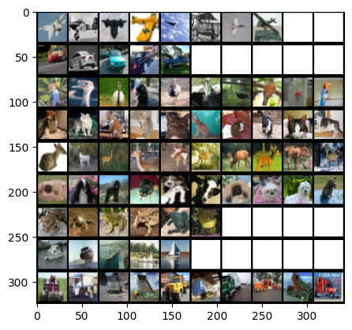

```python
def imshow(img):
    img = img / 2 + 0.5     # unnormalize
    npimg = img.numpy()
    plt.imshow(np.transpose(npimg, (1, 2, 0)))
    plt.show()

def misclassified(class_number):
    incorrect_indices = np.where((ytest_predict != ytest) & (ytest_predict == class_number))[0]
    mislabelled = {}
    for i in range(10):
        if i != class_number:
            mislabelled[i] = []

    #add incorrectly classified images to documentary, with the key as their correct classification
    for index in incorrect_indices:
        mislabelled[ytest[index]].append(testset[index][0]/2 + 0.5)

    #white tensore image for filling rows that don't have 10 misclassifications
    white_tensor = torch.ones_like(testset[0][0])
    grids = []

    for i in range(10):
        if i != class_number:
            while len(mislabelled[i]) < 10:
                mislabelled[i].append(white_tensor)

            grid = torchvision.utils.make_grid(mislabelled[i][:10], nrow=10)
            grids.append(grid)

    stacked_grids = torch.cat(grids, dim=1)

    plt.imshow(np.transpose(stacked_grids, (1, 2, 0)))
    plt.show()





misclassified(7)
```

# Question 6 (Expected) - Comparison of different features

In the deep learning notebook the CIFAR-10 classification code using SVM utilizes a histogram of oriented gradients features followed by a PCA transformation for dimensionality reduction. Using the mini-CIFAR-10 dataset compare the following three feature front-ends using SVM classificaiton (use the same parameters as the deep learning notebook):

1. Flatten the training images to a single (32 * 32 * 3) vector
2. Compute the Histogram of Gradients
3. Computer the Histogram of Gradients followed by PCA (as done in the deep learning notebook).

Compare these three feature front ends by showing the corresponding classification accurarcy and confusion matrices for each one.

```python
from skimage.feature import hog
from sklearn.decomposition import PCA
```

```python
# Your code goes here
train_n_samples = len(trainset.data)
test_n_samples = len(testset.data)


Xtrain = trainset.data
Xtest  = testset.data




Xtrain_hog = []
for i in range(len(Xtrain)):
    fd  = hog(Xtrain[i] , orientations=9 , pixels_per_cell = (8,8),
                     cells_per_block = (2,2) , visualize = False, channel_axis=-1)
    Xtrain_hog.append(fd)

Xtrain_hog = np.array(Xtrain_hog)


Xtest_hog = []
for i in range(len(Xtest)):
    fd = hog(Xtest[i] , orientations=9 , pixels_per_cell = (8,8),
                     cells_per_block = (2,2) , visualize = False, channel_axis=-1)
    Xtest_hog.append(fd)


Xtest_hog = np.array(Xtest_hog)

ytrain = trainset.targets
ytest  = testset.targets

pca = PCA(0.8)
Xtrain_pca = pca.fit_transform(Xtrain_hog)
Xtest_pca  = pca.transform(Xtest_hog)
```

```
              precision    recall  f1-score   support

           0       0.46      0.52      0.49       488
           1       0.57      0.54      0.56       505
           2       0.34      0.37      0.36       512
           3       0.30      0.29      0.30       497
           4       0.40      0.41      0.41       507
           5       0.35      0.31      0.33       488
           6       0.49      0.49      0.49       491
           7       0.54      0.46      0.50       495
           8       0.56      0.65      0.60       504
           9       0.52      0.50      0.51       513

    accuracy                           0.45      5000
   macro avg       0.45      0.45      0.45      5000
weighted avg       0.45      0.45      0.45      5000
```

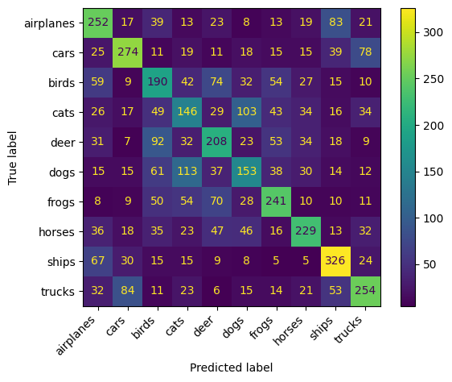

```
CPU times: total: 5min 2s
Wall time: 5min 21s
```

```python
%%time

Xtrain_flat = Xtrain.reshape(len(Xtrain), -1)
Xtest_flat = Xtest.reshape(len(Xtest), -1)

#HOG training for SVM
clf = svm.SVC(C=10, cache_size=10000)
clf.fit(Xtrain_flat, ytrain)

ytest_predict  = clf.predict(Xtest_flat)
print(classification_report(ytest, ytest_predict))


color = 'white'
cm_sv = confusion_matrix(ytest, ytest_predict)
disp = ConfusionMatrixDisplay(cm_sv, display_labels=['airplanes', 'cars', 'birds', 'cats', 'deer', 'dogs', 'frogs', 'horses', 'ships', 'trucks'])
disp.plot()
plt.xticks(rotation=45, ha='right')
plt.show()
```

```
              precision    recall  f1-score   support

           0       0.57      0.65      0.60       488
           1       0.70      0.72      0.71       505
           2       0.45      0.49      0.47       512
           3       0.40      0.38      0.39       497
           4       0.49      0.50      0.50       507
           5       0.44      0.39      0.41       488
           6       0.61      0.64      0.62       491
           7       0.65      0.58      0.62       495
           8       0.64      0.64      0.64       504
           9       0.68      0.64      0.66       513

    accuracy                           0.56      5000
   macro avg       0.56      0.56      0.56      5000
weighted avg       0.56      0.56      0.56      5000
```

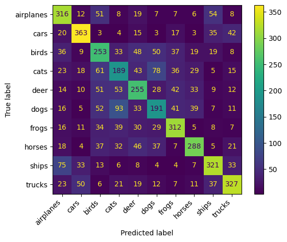

```
CPU times: total: 24.5 s
Wall time: 26.4 s
```

```python
%%time

#HOG training for SVM
clf = svm.SVC(C=10, cache_size=10000)
clf.fit(Xtrain_hog, ytrain)

ytest_predict  = clf.predict(Xtest_hog)
print(classification_report(ytest, ytest_predict))


color = 'white'
cm_sv = confusion_matrix(ytest, ytest_predict)
disp = ConfusionMatrixDisplay(cm_sv, display_labels=['airplanes', 'cars', 'birds', 'cats', 'deer', 'dogs', 'frogs', 'horses', 'ships', 'trucks'])
disp.plot()
plt.xticks(rotation=45, ha='right')
plt.show()
```

```
              precision    recall  f1-score   support

           0       0.55      0.62      0.58       488
           1       0.69      0.70      0.69       505
           2       0.47      0.47      0.47       512
           3       0.36      0.35      0.36       497
           4       0.48      0.48      0.48       507
           5       0.41      0.38      0.39       488
           6       0.58      0.63      0.61       491
           7       0.62      0.56      0.59       495
           8       0.61      0.64      0.62       504
           9       0.67      0.64      0.65       513

    accuracy                           0.55      5000
   macro avg       0.55      0.55      0.55      5000
weighted avg       0.55      0.55      0.55      5000
```

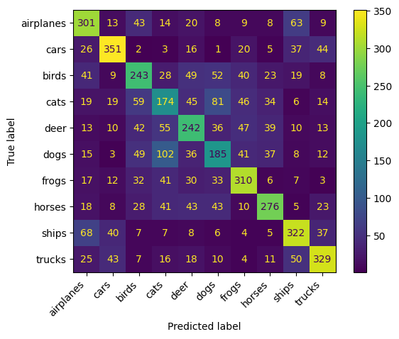

```
CPU times: total: 13.5 s
Wall time: 15.2 s
```

```python
%%time

#PCA training on SVM
clf = svm.SVC(C=10, cache_size=10000)
clf.fit(Xtrain_pca, ytrain)

ytest_predict  = clf.predict(Xtest_pca)
print(classification_report(ytest, ytest_predict))


color = 'white'
cm_sv = confusion_matrix(ytest, ytest_predict)
disp = ConfusionMatrixDisplay(cm_sv, display_labels=['airplanes', 'cars', 'birds', 'cats', 'deer', 'dogs', 'frogs', 'horses', 'ships', 'trucks'])
disp.plot()
plt.xticks(rotation=45, ha='right')
plt.show()
```

# QUESTION 7 (Basic) - Deep learning classification

Retrain the deep neural network specified in the deep learning notebook. You will need to install PyTorch for your system. You don't need to use the GPU unless you have one and can set it up. Your training time will depend on your hardware on my laptop with CPU it takes about 4 minutes and with GPU about 2 minutes. It should not be more than 30 minutes even on an old slow laptop. Another option is to use Google Colab.

Once you have trained and evaluated the network and got numbers similar to the deep learning notebook change the batch size to 16. Repeat the training and report on how the accuracy and training time changed.

```python
import torch.nn as nn
import torch.nn.functional as F
from torchsummary import summary
import torch.optim as optim

class Net(nn.Module):
    def __init__(self):
        super().__init__()
        self.conv1 = nn.Conv2d(3,32,5)
        self.pool = nn.MaxPool2d(2, 2)
        self.conv2 = nn.Conv2d(32, 32, 5)
        self.fc1 = nn.Linear(32 * 5 * 5, 120)
        self.fc2 = nn.Linear(120, 84)
        self.fc3 = nn.Linear(84, 10)

    def forward(self, x):
        x = self.pool(F.relu(self.conv1(x)))
        x = self.pool(F.relu(self.conv2(x)))
        x = torch.flatten(x, 1) # flatten all dimensions except batch
        x = F.relu(self.fc1(x))
        x = F.relu(self.fc2(x))
        x = self.fc3(x)
        return x

dev = "cpu"
device = torch.device(dev)

net = Net()
net.to(device)


criterion = nn.CrossEntropyLoss()
optimizer = optim.SGD(net.parameters(), lr=0.001, momentum=0.9)
```

```python
trainset = torchvision.datasets.CIFAR10(root='./data', train=True,
                                        download=True, transform=transform)
trainloader = torch.utils.data.DataLoader(trainset, batch_size=32,
                                          shuffle=True, num_workers=4)

testset = torchvision.datasets.CIFAR10(root='./data', train=False,
                                       download=True, transform=transform)
testloader = torch.utils.data.DataLoader(testset, batch_size=32,
                                         shuffle=False, num_workers=4)
```

```
Files already downloaded and verified
Files already downloaded and verified
```

```python
%%time
for epoch in range(20):  # loop over the dataset multiple times

    running_loss = 0.0
    for i, data in enumerate(trainloader, 0):
        # get the inputs; data is a list of [inputs, labels]
        inputs, labels = data
        inputs, labels = inputs.to(device,non_blocking=True), labels.to(device, non_blocking=True)
        # zero the parameter gradients
        optimizer.zero_grad()

        # forward + backward + optimize
        outputs = net(inputs)
        loss = criterion(outputs, labels)
        loss.backward()
        optimizer.step()

        # print statistics
        running_loss += loss.item()

        if i % 400 == 399:    # print every 400 mini-batches
            print('[%d, %5d] loss: %.3f' %
                  (epoch + 1, i + 1, running_loss / 2000))
            running_loss = 0.0

print('Finished Training')
```

```
[1,   400] loss: 0.024
[1,   800] loss: 0.026
[1,  1200] loss: 0.023
[1,  1600] loss: 0.025
[1,  2000] loss: 0.032
[1,  2400] loss: 0.032
[1,  2800] loss: 0.029
[2,   400] loss: 0.024
[2,   800] loss: 0.022
[2,  1200] loss: 0.025
[2,  1600] loss: 0.031
[2,  2000] loss: 0.029
[2,  2400] loss: 0.031
[2,  2800] loss: 0.034
[3,   400] loss: 0.022
```

[output cut: 128 more lines]

```python
def test_accuracy(net, testloader, device):
    correct = 0

    # since we're not training, we don't need to calculate the gradients for our outputs
    with torch.no_grad():
        net.eval()
        for images, labels in testloader:
            images, labels = images.to(device), labels.to(device)
            #  = images + 0.2 * torch.randn(images.shape).to(device)

            # calculate outputs by running images through the network
            outputs = net(images)

            # the class with the highest energy is what we choose as prediction
            predicted = torch.max(outputs.data, 1)[1]

            correct += (predicted == labels).sum().item()

    return correct / len(testloader.dataset)


def test_accuracy_per_class(net, testloader, device):
    correct_pred = {classname: 0 for classname in trainset.classes}
    total_pred = {classname: 0 for classname in trainset.classes}

    with torch.no_grad():
        net.eval()
        for images, labels in testloader:
            images, labels = images.to(device), labels.to(device)

            outputs = net(images)
            predicted = torch.max(outputs.data, 1)[1]

            # collect the correct predictions for each class
            for label, prediction in zip(labels, predicted):
                if label == prediction:
                    correct_pred[trainset.classes[label]] += 1
                total_pred[trainset.classes[label]] += 1

    accuracy_per_class = {classname: 0 for classname in trainset.classes}
    for classname, correct_count in correct_pred.items():
        accuracy = (100 * float(correct_count)) / total_pred[classname]
        accuracy_per_class[classname] = accuracy

    return accuracy_per_class


test_acc = test_accuracy(net, testloader, dev)
print(f'Best trial test set accuracy: {test_acc}')

overall_accuracy = test_accuracy(net, testloader, dev)

print(
    'Overall accuracy of the network  '
    f'{(overall_accuracy * 100):.2f} %\n'
    'on the 10000 test images'
)

accuracy_per_class = test_accuracy_per_class(net, testloader, dev)

print('Accuracy per class\n')
for classname, accuracy in accuracy_per_class.items():
    print(f'{classname:12s} {accuracy:.2f} %')
```

```
Best trial test set accuracy: 0.6901
Overall accuracy of the network  69.01 %
on the 10000 test images
Accuracy per class

airplane     76.50 %
automobile   81.80 %
bird         64.50 %
cat          55.90 %
deer         66.10 %
dog          50.20 %
frog         72.20 %
horse        69.50 %
ship         79.00 %
truck        74.40 %
```

```python
trainset = torchvision.datasets.CIFAR10(root='./data', train=True,
                                        download=True, transform=transform)
trainloader = torch.utils.data.DataLoader(trainset, batch_size=16,
                                          shuffle=True, num_workers=4)

testset = torchvision.datasets.CIFAR10(root='./data', train=False,
                                       download=True, transform=transform)
testloader = torch.utils.data.DataLoader(testset, batch_size=16,
                                         shuffle=False, num_workers=4)
```

```
Files already downloaded and verified
Files already downloaded and verified
```

```python
%%time
for epoch in range(20):  # loop over the dataset multiple times

    running_loss = 0.0
    for i, data in enumerate(trainloader, 0):
        # get the inputs; data is a list of [inputs, labels]
        inputs, labels = data
        inputs, labels = inputs.to(device,non_blocking=True), labels.to(device, non_blocking=True)
        # zero the parameter gradients
        optimizer.zero_grad()

        # forward + backward + optimize
        outputs = net(inputs)
        loss = criterion(outputs, labels)
        loss.backward()
        optimizer.step()

        # print statistics
        running_loss += loss.item()

        if i % 400 == 399:    # print every 400 mini-batches
            print('[%d, %5d] loss: %.3f' %
                  (epoch + 1, i + 1, running_loss / 2000))
            running_loss = 0.0

print('Finished Training')
```

```
[1,   400] loss: 0.112
[1,   800] loss: 0.119
[1,  1200] loss: 0.126
[1,  1600] loss: 0.121
[1,  2000] loss: 0.128
[1,  2400] loss: 0.128
[1,  2800] loss: 0.123
[2,   400] loss: 0.110
[2,   800] loss: 0.108
[2,  1200] loss: 0.109
[2,  1600] loss: 0.116
[2,  2000] loss: 0.115
[2,  2400] loss: 0.114
[2,  2800] loss: 0.117
[3,   400] loss: 0.097
```

[output cut: 128 more lines]

```python
def test_accuracy(net, testloader, device):
    correct = 0

    # since we're not training, we don't need to calculate the gradients for our outputs
    with torch.no_grad():
        net.eval()
        for images, labels in testloader:
            images, labels = images.to(device), labels.to(device)
            #  = images + 0.2 * torch.randn(images.shape).to(device)

            # calculate outputs by running images through the network
            outputs = net(images)

            # the class with the highest energy is what we choose as prediction
            predicted = torch.max(outputs.data, 1)[1]

            correct += (predicted == labels).sum().item()

    return correct / len(testloader.dataset)


def test_accuracy_per_class(net, testloader, device):
    correct_pred = {classname: 0 for classname in trainset.classes}
    total_pred = {classname: 0 for classname in trainset.classes}

    with torch.no_grad():
        net.eval()
        for images, labels in testloader:
            images, labels = images.to(device), labels.to(device)

            outputs = net(images)
            predicted = torch.max(outputs.data, 1)[1]

            # collect the correct predictions for each class
            for label, prediction in zip(labels, predicted):
                if label == prediction:
                    correct_pred[trainset.classes[label]] += 1
                total_pred[trainset.classes[label]] += 1

    accuracy_per_class = {classname: 0 for classname in trainset.classes}
    for classname, correct_count in correct_pred.items():
        accuracy = (100 * float(correct_count)) / total_pred[classname]
        accuracy_per_class[classname] = accuracy

    return accuracy_per_class


test_acc = test_accuracy(net, testloader, dev)
print(f'Best trial test set accuracy: {test_acc}')

overall_accuracy = test_accuracy(net, testloader, dev)

print(
    'Overall accuracy of the network  '
    f'{(overall_accuracy * 100):.2f} %\n'
    'on the 10000 test images'
)

accuracy_per_class = test_accuracy_per_class(net, testloader, dev)

print('Accuracy per class\n')
for classname, accuracy in accuracy_per_class.items():
    print(f'{classname:12s} {accuracy:.2f} %')
```

```
Best trial test set accuracy: 0.6998
Overall accuracy of the network  69.98 %
on the 10000 test images
Accuracy per class

airplane     75.90 %
automobile   86.30 %
bird         63.70 %
cat          49.90 %
deer         60.60 %
dog          60.30 %
frog         75.40 %
horse        75.50 %
ship         75.70 %
truck        76.50 %
```

- the training time was minimal, with about a minute of difference. There was about a 3 times difference in terms of the loss function's output, going from 0.014 to 0.039 when changing frombatches of 32 to 16.
- In terms of classification accuracy, the two methods were almost idential, with the 32 batch size having an accuracy of 69.01%, whereas the 16 batch size had 69.98%, so a 1% difference.

# QUESTION 8 (EXPECTED) - Deep learning classification of noisy images

In this question you will explore the effect of adding noise to the classification of the CIFAR-10 dataset. You can add random noise with a mean of 0 and standard deviation of 1 to a tensor using the *torch.randn*. For example: x = x + torch.randn(x.shape) will add noise to the tensor x. Add noise with a mean of 0 and a standard deviation of 0.2 to the images of the CIFAR-10 dataset. First see how the images with the added noise will look by adding the noise in the *imshow* function. Then check how the classification accuracy on the test set is affected if you add noise to the test but NOT the training set.

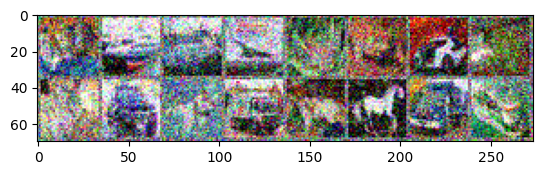

```
GroundTruth:    cat  ship  ship plane  frog  frog   car  frog
```

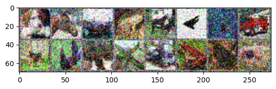

```
GroundTruth:    dog horse  ship  frog horse plane  deer truck
```

```python
# Your code goes here
def imshow(img):
    img = np.clip(img / 2 + 0.5  + np.random.normal(0, 0.2, img.shape), 0, 1)   # unnormalize and add noise then clip
    npimg = img.numpy()
    plt.imshow(np.transpose(npimg, (1, 2, 0)))
    plt.show()


dataiter = iter(testloader)
images, labels = next(dataiter)

# print images
imshow(torchvision.utils.make_grid(images))
print('GroundTruth: ', ' '.join('%5s' % classes[labels[j]] for j in range(8)))

images, labels = next(dataiter)

# print images
imshow(torchvision.utils.make_grid(images))
print('GroundTruth: ', ' '.join('%5s' % classes[labels[j]] for j in range(8)))
```

```python
def test_accuracy(net, testloader, device):
    correct = 0

    # since we're not training, we don't need to calculate the gradients for our outputs
    with torch.no_grad():
        net.eval()
        for images, labels in testloader:
            labels = labels.to(device)
            images = (images + 0.2 * torch.randn(images.shape)).to(device)

            # calculate outputs by running images through the network
            outputs = net(images)

            # the class with the highest energy is what we choose as prediction
            predicted = torch.max(outputs.data, 1)[1]

            correct += (predicted == labels).sum().item()

    return correct / len(testloader.dataset)


def test_accuracy_per_class(net, testloader, device):
    correct_pred = {classname: 0 for classname in trainset.classes}
    total_pred = {classname: 0 for classname in trainset.classes}

    with torch.no_grad():
        net.eval()
        for images, labels in testloader:
            images, labels = images.to(device), labels.to(device)
            images = (images + 0.2 * torch.randn(images.shape)).to(device)

            outputs = net(images)
            predicted = torch.max(outputs.data, 1)[1]

            # collect the correct predictions for each class
            for label, prediction in zip(labels, predicted):
                if label == prediction:
                    correct_pred[trainset.classes[label]] += 1
                total_pred[trainset.classes[label]] += 1

    accuracy_per_class = {classname: 0 for classname in trainset.classes}
    for classname, correct_count in correct_pred.items():
        accuracy = (100 * float(correct_count)) / total_pred[classname]
        accuracy_per_class[classname] = accuracy

    return accuracy_per_class


test_acc = test_accuracy(net, testloader, dev)
print(f'Best trial test set accuracy: {test_acc}')

overall_accuracy = test_accuracy(net, testloader, dev)

print(
    'Overall accuracy of the network  '
    f'{(overall_accuracy * 100):.2f} %\n'
    'on the 10000 test images'
)

accuracy_per_class = test_accuracy_per_class(net, testloader, dev)

print('Accuracy per class\n')
for classname, accuracy in accuracy_per_class.items():
    print(f'{classname:12s} {accuracy:.2f} %')
```

```
Best trial test set accuracy: 0.6015
Overall accuracy of the network  59.83 %
on the 10000 test images
Accuracy per class

airplane     62.20 %
automobile   71.90 %
bird         43.30 %
cat          36.10 %
deer         68.70 %
dog          34.40 %
frog         83.80 %
horse        60.40 %
ship         56.50 %
truck        77.20 %
```

- The accuracy is about 10% lower (~60% rather than ~69%) than on the images without noise, which is pretty good considering how difficult it is for me as a human to tell what some of those images are after the noise is applied
- The reason that the two first lines have slightly different accuracy is because they're generated form two seperate function calls where the random noise is generated within the function, and so won't be the same.